# Notes on Chapter 9

The Caveman Coder

2026-01-01

# Spatial modeling of geostatistical data: Malaria in the Gambia

Aim: show how to fit a geostatistical model to predict malaria prevalence in the Gambia using stochastic partial differential equation (SPDE) and plot the results by means of interactive maps created using **leaflet**.

## Data

Loading the `gambia` dataset from the **geoR** package:

```r
library(geoR)
data(gambia)
```

Data dictionary: - `x`: the x-coordinate of the village (UTM).  
- `y`: the y-coordinate of the village (UTM).  
- `pos`: presence (1) or absence (0) of malaria in a blood sample taken from a child.  
- `age`: age of the child, in days.  
- `netuse`: indicator variable denoting whether the child regularly sleeps under a bed net.  
- `treated`: indicator variable denoting whether the bed net is treated or not.  
- `green`: satellite-derived measure of the greenness of vegetation in the vicinity of the village.  
- `phc`: indicator variable denoting the presence or absence of a health center in the village.

```r
head(gambia)
```

```
##             x       y pos  age netuse treated green phc
## 1850 349631.3 1458055   1 1783      0       0 40.85   1
## 1851 349631.3 1458055   0  404      1       0 40.85   1
## 1852 349631.3 1458055   0  452      1       0 40.85   1
## 1853 349631.3 1458055   1  566      1       0 40.85   1
## 1854 349631.3 1458055   0  598      1       0 40.85   1
## 1855 349631.3 1458055   1  590      1       0 40.85   1
```

## Data preparation

Data in `gambia` are given at an individual level. For the analysis, this data need to be aggregated by village.

### Prevalence

Inspecting the data:

```r
dim(gambia)
```

```
## [1] 2035    8
```

```r
dim(unique(gambia[, c("x", "y")]))
```

```
## [1] 65  2
```

Calculating the prevalence of malaria cases:

```r
library(dplyr)
d <- gambia |> group_by(x, y) |>
  summarize(
    total = n(),
    positive = sum(pos),
    prev = positive / total
  )
```

[output not shown]

```r
head(d)
```

```
## # A tibble: 6 × 5
## # Groups:   x [6]
##         x       y total positive  prev
##     <dbl>   <dbl> <int>    <dbl> <dbl>
## 1 349631. 1458055    33       17 0.515
## 2 358543. 1460112    63       19 0.302
## 3 360308. 1460026    17        7 0.412
## 4 363796. 1496919    24        8 0.333
## 5 366400. 1460248    26       10 0.385
## 6 366688. 1463002    18        7 0.389
```

### Transforming coordinates

`leaflet()` expects data to be specified in geographic coordinates (long/lat). The coordinates in the `gambia` dataset are in UTM format (easting/northing).

Transforming the UTM coordinates using `st_transform()` from the **sf** package:

```r
library(sf)
sf <- st_as_sf(
  as.data.frame(d),
  coords = c("x", "y"),
  crs = "+proj=utm +zone=28"
)

sft <- st_transform(sf, crs = 4326)
```

Adding the longitude and latitude variables to dataframe `d`:

```r
d[, c("long", "lat")] <- st_coordinates(sft)
head(d)
```

```
## # A tibble: 6 × 7
## # Groups:   x [6]
##         x       y total positive  prev  long   lat
##     <dbl>   <dbl> <int>    <dbl> <dbl> <dbl> <dbl>
## 1 349631. 1458055    33       17 0.515 -16.4  13.2
## 2 358543. 1460112    63       19 0.302 -16.3  13.2
## 3 360308. 1460026    17        7 0.412 -16.3  13.2
## 4 363796. 1496919    24        8 0.333 -16.3  13.5
## 5 366400. 1460248    26       10 0.385 -16.2  13.2
## 6 366688. 1463002    18        7 0.389 -16.2  13.2
```

### Mapping prevalence

Creating an interactive map in **leaflet** with circles whose color correspond to the prevalence rates of malaria:

```r
library(leaflet)
library(viridis)
pal <- colorBin("viridis", bins = c(0, 0.25, 0.5, 0.75, 1))

leaflet(d) |>
  addProviderTiles(providers$CartoDB.Positron) |>
  addCircles(
    lng = ~ long,
    lat = ~ lat,
    color = ~ pal(prev)
  ) |>
  addLegend(
    "bottomright",
    pal = pal,
    values = ~ prev,
    title = "Prev."
  ) |>
  addScaleBar(position = c("bottomleft"))
```

[interactive chart not shown]

Malaria prevalence in The Gambia.

### Environmental covariates

Aim: to model malaria prevalence in the Gambia using a covariate that indicates the elevation.

Obtaining the elevation information using the function `elevation_30s()` from the **geodata** package:

```r
library(geodata)
r <- elevation_30s(country = "GMB", path = tempdir())
```

The function `elevation_30s()` obtains elevation for any country (specified using the ISO country code) at a resolution of 30 arc seconds (about 1 km).

Adding elevation data to the leaflet plot using `addRasterImage()`:

```r
pal <- colorNumeric(
  "viridis",
  values(r),
  na.color = "transparent"
)

leaflet() |>
  addProviderTiles(providers$CartoDB.Positron) |>
  addRasterImage(
    r,
    colors = pal,
    opacity = 0.5
  ) |>
  addLegend(
    "bottomright",
    pal = pal,
    values = values(r),
    title = "Elevation"
  ) |>
  addScaleBar(position = c("bottomleft"))
```

[interactive chart not shown]

Adding the elevation values (by extracting them using `terra::extract()`) to dataframe `d` to be able to use it as a covariate in the model:

```r
d$cov <- terra::extract(r, d[, c("long", "lat")])$GMB_elv_msk
```

Viewing the final dataset:

```r
head(d)
```

```
## # A tibble: 6 × 8
## # Groups:   x [6]
##         x       y total positive  prev  long   lat   cov
##     <dbl>   <dbl> <int>    <dbl> <dbl> <dbl> <dbl> <dbl>
## 1 349631. 1458055    33       17 0.515 -16.4  13.2    15
## 2 358543. 1460112    63       19 0.302 -16.3  13.2    33
## 3 360308. 1460026    17        7 0.412 -16.3  13.2    32
## 4 363796. 1496919    24        8 0.333 -16.3  13.5    20
## 5 366400. 1460248    26       10 0.385 -16.2  13.2    29
## 6 366688. 1463002    18        7 0.389 -16.2  13.2    18
```

## Modeling

Aim: Create a model to predict malaria prevalence in The Gambia using the SPDE approach and the **R-INLA** package.

### Model

Conditional on the true prevalence $P(\mathbf{x}_i)$ at location $\mathbf{x}_i, i = 1, ..., n$, the number of positive results $Y_i$ out of $N_i$ people sampled follows a binomial distribution:
$$Y_i|P(\mathbf{x}_i) \sim Binomial(N_i, P(\mathbf{x}_i)), \\
logit(P(\mathbf{x}_i)) = \beta_0 + \beta_1 \times \text{elevation} +
S(\mathbf{x}_i)$$

### Mesh construction

Similar to what was done in chapter 8, it is necessasry to build a triangulated mesh that covers The Gambia over which to make the random field discretization (is it because the model follows a binomial distribution instead of normal?).

Building the triangulated mesh using the function `inla.mesh.2d()` from the **R-INLA** package:

```r
library(INLA)
coo <- cbind(d$long, d$lat)
# mesh <- inla.mesh.2d(
mesh <- fmesher::fm_mesh_2d_inla(
  loc = coo,
  max.edge = c(0.1, 5),
  cutoff = 0.01
)
```

Note: `inla.mesh.2d()` was deprecated. The newer function is `fmesher::fm_mesh_2d_inla()`.

Inspecting the number of mesh vertices:

```r
mesh$n
```

```
## [1] 673
```

Plotting the mesh object:

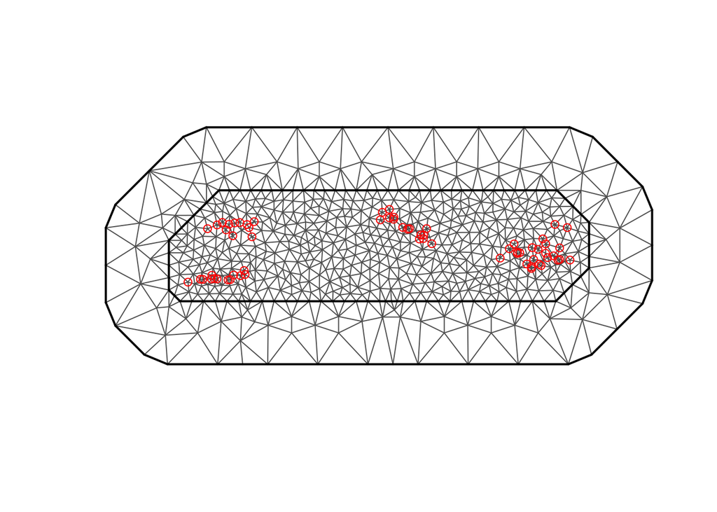

Triangulated mesh used to build the SPDE model.

```r
plot(mesh)
points(coo, col = "red")
```

### Building the SPDE model on the mesh

Using the `inla.spded2.matern()` function to build the SPDE model:

```r
spde <- inla.spde2.matern(
  mesh = mesh,
  alpha = 2,
  constr = TRUE
)
```

Here the argument `constr` was set to `TRUE` to impose an integrate-to-zero constraint. `alpha` is a parameter related to the smoothness parameter of the process $\alpha = v + d/2$. If we want the smoothness parameter $v$ to equal 1, the value of `alpha` becomes 2 (d = 2 in our spatial case).

### Index set

Generating the indes set for the SPDE model using `inla.spde.make.index()`:

```r
indexs <- inla.spde.make.index("s", spde$n.spde)
lengths(indexs)
```

```
##       s s.group  s.repl
##     673     673     673
```

### Projection matrix

Building the projection matrix $A$ that will be used to project the spatially continuous Gaussian random field from the observations to the mesh nodes.

Using `inla.spde.make.A()` function to create the projection matrix:

```r
A <- inla.spde.make.A(mesh = mesh, loc = coo)
```

### Prediction data

Extracting the locations from the raster data (the locations are where the model will predict the prevalence from) using the `crds()` function from **terra**:

```r
dp <- terra::crds(r)
dim(dp)
```

```
## [1] 12847     2
```

There are 12847 points – these are location points that the model will predict from.

Lowering the resolution of the raster using the `aggregate()` function from **terra** (to make the computation faster):

```r
ra <- terra::aggregate(r, fact = 5, fun = mean)
```

Extracting prediction points from the aggregated `r` raster data:

```r
dp <- terra::crds(ra)
dp <- as.data.frame(dp)
dim(dp)
```

```
## [1] 411   2
```

Now we have fewer prediction points.

Extracting the prediction points (location points) again, this time as variable `coop`:

```r
coop <- terra::crds(ra)
```

Adding to the prediction data `dp` a column with elevation values for the prediction coordinates:

```r
dp$cov <- terra::extract(ra, coop)[, 1]
head(dp)
```

```
##           x        y   cov
## 1 -15.10417 13.77083 13.40
## 2 -15.06250 13.77083 14.12
## 3 -15.02083 13.77083 19.04
## 4 -14.97917 13.77083 30.00
## 5 -14.93750 13.77083 43.24
## 6 -15.35417 13.72917 25.24
```

Creating another projection matrix for projevting the spatially continuous Gaussian random field from the prediction locations to the mesh nodes:

```r
Ap <- inla.spde.make.A(mesh = mesh, loc = coop)
```

### Stack with data for estimation and prediction

Using the `inla.stack()` function to organize data, effects, and prediction matrices:

```r
# stack for estimation
stk.e <- inla.stack(
  tag = "est",
  data = list(y = d$positive, numtrials = d$total),
  A = list(1, A),
  effects = list(data.frame(b0 = 1, elevation = d$cov), s = indexs)
)

# stack for prediction
stk.p <- inla.stack(
  tag = "pred",
  data = list(y = NA, numtrials = NA),
  A = list(1, Ap),
  effects = list(data.frame(b0 = 1, elevation = dp$cov), s = indexs)
)

# the full stack
stk.full <- inla.stack(stk.e, stk.p)
```

### Model formula

Specifying the model formula by including in the left-hand side the response variable and in the right-hand side the fixed and random effects:

```r
formula <- y ~ 0 + b0 + elevation + f(s, model = spde)
```

### `inla()` call

Fitting the model by calling `inla()` and using the default priors in **R-INLA**:

```r
res <- inla(
  formula,
  family = "binomial",
  Ntrials = numtrials,
  control.family = list(link = "logit"),
  data = inla.stack.data(stk.full),
  control.predictor = list(
    compute = TRUE,
    link = 1,
    A = inla.stack.A(stk.full)
  ),
  control.compute = list(return.marginals.predictor = TRUE)
)
```

The argument `control.predictor` set to `compute = TRUE` will allow the model to compute the posteriors of the predictors. `link` when set to `1` will allow the model to compute the fitted values (the `` res$summary.fitted.values`` and ``res$marginals.fitted.values`) with the same link function as the`family` specified.

## Mapping malaria prevalence

Obtaining the indices that correspond to the prediction locations:

```r
index <- inla.stack.index(stack = stk.full, tag = "pred")$data
```

Extracting the vectors with the mean prevalence and the upper and lower limits of 95% credible intervals:

```r
prev_mean <- res$summary.fitted.values[index, "mean"]
prev_ll <- res$summary.fitted.values[index, "0.025quant"]
prev_ul <- res$summary.fitted.values[index, "0.975quant"]
```

Creating a map with the predicted prevalence at the prediction locations given in `coop`:

```r
pal <- colorNumeric(
  palette = "viridis",
  domain = c(0, 1),
  na.color = "transparent"
)

leaflet() |>
  addProviderTiles(providers$CartoDB.Positron) |>
  addCircles(
    lng = coop[, 1],
    lat = coop[, 2],
    color = pal(prev_mean)
  )  |>
  addLegend(
    "bottomright",
    pal = pal,
    values = prev_mean,
    title = "Prev."
  ) |>
  addScaleBar(position = c("bottomleft"))
```

[interactive chart not shown]

Map of malaria prevalence predictions in The Gambia creatd with `leaflet()` and `addCircles()`.

Plotting the prevalence prediction as a raster:

```r
# create a SpatVector object
sv <- terra::vect(
  coop,
  atts = data.frame(
    prev_mean = prev_mean,
    prev_ll = prev_ll,
    prev_ul = prev_ul
  ),
  crs = "+proj=longlat +datum=WGS84"
)

# rasterize
r_prev_mean <- terra::rasterize(
  x = sv, y = ra,
  field = "prev_mean",
  fun = mean
)

# plotting the raster with the prevalence values in a map
pal <- colorNumeric("viridis", c(0, 1), na.color = "transparent")

leaflet() |>
  addProviderTiles(providers$CartoDB.Positron) |>
  addRasterImage(
    r_prev_mean,
    colors = pal,
    opacity = 0.5
  ) |>
  addLegend(
    "bottomright",
    pal = pal,
    values = values(r_prev_mean),
    title = "Prev."
  ) |>
  addScaleBar(position = c("bottomleft"))
```

[interactive chart not shown]

Map of malaria prevalence predictions in The Gambia created with `leaflet()` and `addRasterImage()`.

Using the same approach to create maps with the lower and upper limits of the prevalence predictions:

```r
r_prev_ll <- terra::rasterize(
  x = sv, y = ra,
  field = "prev_ll",
  fun = mean
)

leaflet() |>
  addProviderTiles(providers$CartoDB.Positron) |>
  addRasterImage(
    r_prev_ll,
    colors = pal,
    opacity = 0.5
  ) |>
  addLegend(
    "bottomright",
    pal = pal,
    values = values(r_prev_ll),
    title = "LL"
  ) |>
  addScaleBar(position = c("bottomright"))
```

[interactive chart not shown]

Map of lower limit of 95% CI of malaria prevalence in The Gambia.

Plot for the upper limit:

```r
r_prev_ul <- terra::rasterize(
  x = sv, y = ra,
  field = "prev_ul",
  fun = mean
)

leaflet() |>
  addProviderTiles(providers$CartoDB.Positron) |>
  addRasterImage(
    r_prev_ul,
    colors = pal,
    opacity = 0.5
  ) |>
  addLegend(
    "bottomright",
    pal = pal,
    values = values(r_prev_ul),
    title = "UL"
  ) |>
  addScaleBar(position = c("bottomleft"))
```

[interactive chart not shown]

Map of upper limit of 95% CI of malaria prevalence in The Gambia.

## Mapping exeedance probabilities

This answers the question “What are the probabilities that malaria prevalence is greater than a particular threshold?”

Calculating the exeedance probabilities if the threshold is 20%:

```r
index <- inla.stack.index(stack = stk.full, tag = "pred")$data

1 - inla.pmarginal(
  q = 0.2,
  marginal = res$marginals.fitted.values[index][[1]]
)
```

```
## [1] 0.7540786
```

Computing the exceedance probabilities for all the prediction locations using the `sapply()` function:

```r
excprob <- sapply(
  res$marginals.fitted.values[index],
  FUN = function(marg){1 - inla.pmarginal(q = 0.20, marginal = marg)}
)

head(excprob)
```

```
## fitted.APredictor.066 fitted.APredictor.067 fitted.APredictor.068
##             0.7540786             0.6812949             0.6439999
## fitted.APredictor.069 fitted.APredictor.070 fitted.APredictor.071
##             0.6205928             0.5719323             0.7658366
```

Making maps of the exceedance probabilities by creating a raster with exceedance probabilities using `rasterize()` and `leaflet()`:

```r
sv$excprob <- excprob
r_excprob <- terra::rasterize(
  x = sv, y = ra,
  field = "excprob",
  fun = mean
)

pal <- colorNumeric("viridis", c(0, 1), na.color = "transparent")

leaflet() |>
  addProviderTiles(providers$CartoDB.Positron) |>
  addRasterImage(
    r_excprob,
    colors = pal,
    opacity = 0.5
  ) |>
  addLegend(
    "bottomright",
    pal = pal,
    values = values(r_excprob),
    title = "P(p>0.2)"
  ) |>
  addScaleBar(position = c("bottomleft"))
```

[interactive chart not shown]

Map of malaria probability prevalence in The Gambia exceeding 20%